# Modeling and prediction for movies

## Setup

### Load packages

```r
library(ggplot2)
library(dplyr)
library(statsr)
library(GGally)
```

### Load data

```r
load("movies.Rdata")
```

## Part 1: Data

These data are a random sample of movies from two survey based movie ratings websites. Because these data are a random sample they are generalizable, but only to the two movie databases from which they were obtained. The individuals who provide insights to these databases are not selected randomly and do so by choice. This means that there might be a bias in terms of who chooses to participate in the ratings. With that said, I would still use these data to attempt to predict future ratings on these sites as it can be assumed that all ratings are affected by the same biases.

No causal relationships should be drawn from these data.

## Part 2: Research question

What combination of variables from the ratings can be used to best predict the imdb_rating of a movie? This could be useful information for someone trying to create an app that predicts the popularity of a movie without having to collect new survey data. They may not be allowed to directly cite the IMDB rating so they could create a model that tries to accurately predict what that rating would be based on other parameters.

## Part 3: Exploratory data analysis

The numerical variables of interest are imdb_num_votes, critics_score,and audience_score. I will explore these to make sure that they are appropriate to use in a linear model.

Plot of imdb_rating vs. imdb_num_votes

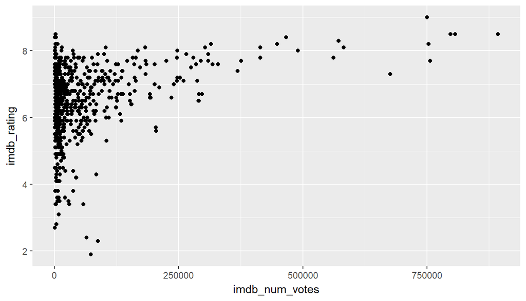

```r
ggplot(movies, aes(imdb_num_votes, imdb_rating)) + geom_point()
```

This relationship does not look linear to me so I will exclude it from the analysis.

Plots of imdb_rating vs. critics score and audience score

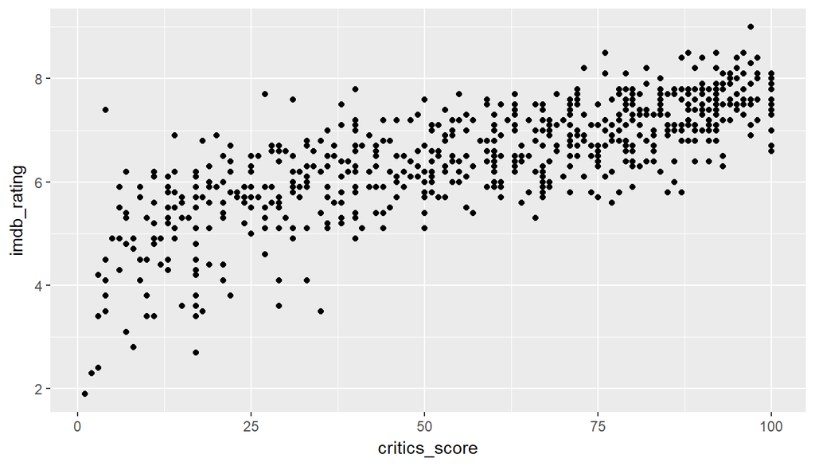

```r
ggplot(movies, aes(critics_score, imdb_rating)) + geom_point()
```

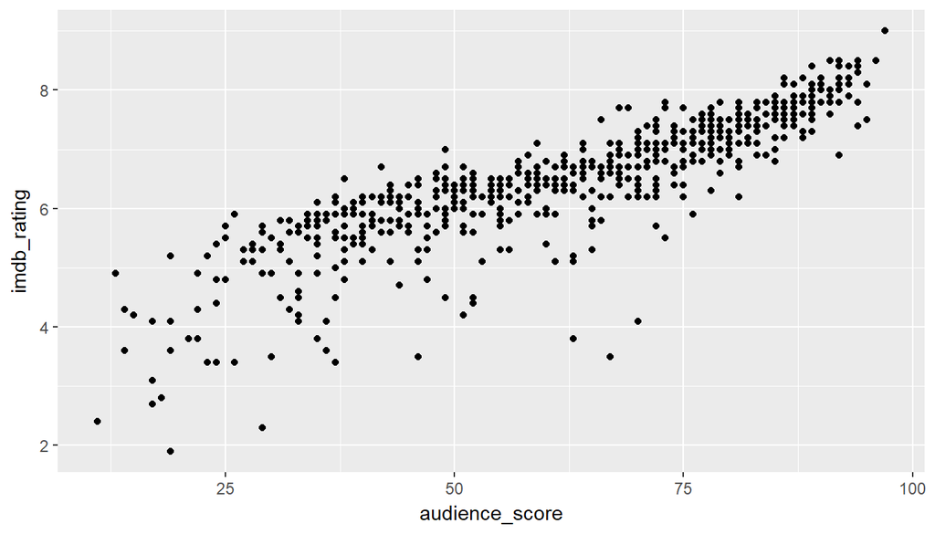

```r
ggplot(movies, aes(audience_score, imdb_rating)) + geom_point()
```

Both of these look linear so they are most likely appropriate to include in the model.

## Part 4: Modeling

Start with the full set of parameters that we are interested in. These are: critics_score, audience_score, oscar nomination and win variables

The reason that I am excluding the other variables is that they do not reflect readily available ratings for the movies in question. Since I am trying to infer the rating from other sources, variables such as actor and director won’t help. Presumably those variables are baked in to the other ratings systems.

I am going to use a backward elimination method, searching for the model that provides the highest adjusted R-squared.

I first start with the full model and then compare the adjusted R-squared to iterations where I drop one variable at a time.

```r
summary(lm(imdb_rating~ critics_score + audience_score + best_pic_nom + best_pic_win + best_actor_win + best_actress_win + best_dir_win, data=movies))$adj.r.squared
```

```
## [1] 0.7972952
```

```r
summary(lm(imdb_rating~ critics_score + audience_score + best_pic_nom + best_pic_win + best_actor_win + best_actress_win, data=movies))$adj.r.squared
```

```
## [1] 0.7970942
```

```r
summary(lm(imdb_rating~ critics_score + audience_score + best_pic_nom + best_pic_win + best_actor_win + best_dir_win, data=movies))$adj.r.squared
```

```
## [1] 0.7968677
```

```r
summary(lm(imdb_rating~ critics_score + audience_score + best_pic_nom + best_pic_win + best_actress_win + best_dir_win, data=movies))$adj.r.squared
```

```
## [1] 0.7966147
```

```r
summary(lm(imdb_rating~ critics_score + audience_score + best_pic_nom + best_actor_win + best_actress_win + best_dir_win, data=movies))$adj.r.squared
```

```
## [1] 0.7975481
```

```r
summary(lm(imdb_rating~ critics_score + audience_score + best_pic_win + best_actor_win + best_actress_win + best_dir_win, data=movies))$adj.r.squared
```

```
## [1] 0.7976094
```

```r
summary(lm(imdb_rating~ critics_score + best_pic_nom + best_pic_win + best_actor_win + best_actress_win + best_dir_win, data=movies))$adj.r.squared
```

```
## [1] 0.5870326
```

```r
summary(lm(imdb_rating~ audience_score + best_pic_nom + best_pic_win + best_actor_win + best_actress_win + best_dir_win, data=movies))$adj.r.squared
```

```
## [1] 0.7522662
```

In the first run, dropping best_pic_nom resulted in the highest adjusted R-squared. I am now going to start with that model and backwards eliminate.

```r
summary(lm(imdb_rating~ critics_score + audience_score + best_pic_win + best_actor_win + best_actress_win + best_dir_win, data=movies))$adj.r.squared
```

```
## [1] 0.7976094
```

```r
summary(lm(imdb_rating~ audience_score + best_pic_win + best_actor_win + best_actress_win + best_dir_win, data=movies))$adj.r.squared
```

```
## [1] 0.7525854
```

```r
summary(lm(imdb_rating~ critics_score + best_pic_win + best_actor_win + best_actress_win + best_dir_win, data=movies))$adj.r.squared
```

```
## [1] 0.5850998
```

```r
summary(lm(imdb_rating~ critics_score + audience_score + best_actor_win + best_actress_win + best_dir_win, data=movies))$adj.r.squared
```

```
## [1] 0.7978405
```

```r
summary(lm(imdb_rating~ critics_score + audience_score + best_pic_win + best_actress_win + best_dir_win, data=movies))$adj.r.squared
```

```
## [1] 0.7968993
```

```r
summary(lm(imdb_rating~ critics_score + audience_score + best_pic_win + best_actor_win + best_dir_win, data=movies))$adj.r.squared
```

```
## [1] 0.7971634
```

```r
summary(lm(imdb_rating~ critics_score + audience_score + best_pic_win + best_actor_win + best_actress_win, data=movies))$adj.r.squared
```

```
## [1] 0.7974088
```

Dropping best_pic_win increased the R-squared of the model. Next backwards elimination:

```r
summary(lm(imdb_rating~ critics_score + audience_score + best_actor_win + best_actress_win + best_dir_win, data=movies))$adj.r.squared
```

```
## [1] 0.7978405
```

```r
summary(lm(imdb_rating~ critics_score + audience_score + best_actor_win + best_actress_win, data=movies))$adj.r.squared
```

```
## [1] 0.7974313
```

```r
summary(lm(imdb_rating~ critics_score + audience_score + best_actor_win + best_dir_win, data=movies))$adj.r.squared
```

```
## [1] 0.7973132
```

```r
summary(lm(imdb_rating~ critics_score + audience_score + best_actress_win + best_dir_win, data=movies))$adj.r.squared
```

```
## [1] 0.7971367
```

```r
summary(lm(imdb_rating~ critics_score + best_actor_win + best_actress_win + best_dir_win, data=movies))$adj.r.squared
```

```
## [1] 0.5848169
```

```r
summary(lm(imdb_rating~ audience_score + best_actor_win + best_actress_win + best_dir_win, data=movies))$adj.r.squared
```

```
## [1] 0.7527681
```

None of these models has a higher adjusted R-sqared. that means that the best model using this method is:

```r
model <- lm(imdb_rating~ critics_score + audience_score + best_actor_win + best_actress_win + best_dir_win, data=movies)
summary(model)
```

```
##
## Call:
## lm(formula = imdb_rating ~ critics_score + audience_score + best_actor_win +
##     best_actress_win + best_dir_win, data = movies)
##
## Residuals:
##      Min       1Q   Median       3Q      Max
## -2.50376 -0.21254  0.01754  0.30679  1.25473
##
## Coefficients:
##                     Estimate Std. Error t value Pr(>|t|)
## (Intercept)         3.625777   0.062687  57.839   <2e-16 ***
## critics_score       0.011500   0.000955  12.043   <2e-16 ***
## audience_score      0.034806   0.001333  26.110   <2e-16 ***
## best_actor_winyes   0.099871   0.055408   1.802   0.0719 .
## best_actress_winyes 0.101187   0.061754   1.639   0.1018
## best_dir_winyes     0.118806   0.078210   1.519   0.1292
## ---
## Signif. codes:  0 '***' 0.001 '**' 0.01 '*' 0.05 '.' 0.1 ' ' 1
##
## Residual standard error: 0.4877 on 645 degrees of freedom
## Multiple R-squared:  0.7994, Adjusted R-squared:  0.7978
## F-statistic: 514.1 on 5 and 645 DF,  p-value: < 2.2e-16
```

## Part 5: Prediction

To test this we will compare this to the recent best picture winner The Shape of Water. This has a critics score of 92, an audience score of 76, won best director, and did not win either acting award. Based on these the predicted rating is:

```r
new_df = data.frame(critics_score = c(92), audience_score = c(76), best_dir_win=c('yes'), best_actor_win = c('no'), best_actress_win = c('no'))

predict(model, new_df, interval="predict")
```

```
##        fit      lwr      upr
## 1 7.447847 6.477872 8.417822
```

Based on the model the rating should be 7.45 with a 95% confidence interval of (6.48, 8.42)

The actual rating of this movie is 7.6.

## Part 6: Conclusion

Our model results indicate that the variables critics_score, audience_score, best_dir_win, best_actor_win, and best_actress_win account for nearly 80% of the variability in imdb_ratings. These five categories would be a good start for someone trying to come up with a new prediction of how imdb_users might rate a movie. I have learned that being nominated for and/or winning best picture does not help predict the score of a movie as much as other acting and directing awards. One shortcoming for this system is for movies that are not rated on Rotten Tomatoes. Any move that does not have scores on that site will not have the required data to use in this model. This model also only takes into account Oscar awards. There are many other awards out there that might help in predicing the ratings of movies.